# Exercises

Estadística avanzada

Septiembre 2017

# 1 Generar secuencias

Rellenar los vectores siguientes:

v1: 1 2 3

v2: 1 2 3 1 2 3 1 2 3

v3: 0 10 20 30 40 50 60 70 80 90 100

v4: 1000 900 800 700 600 500 400 300 200 100 0

v5: 1 1 1 1 1

```r
v1 <- c(1,2,3)
v1
```

```
## [1] 1 2 3
```

```r
v2 <- rep( v1, 3 )
v2
```

```
## [1] 1 2 3 1 2 3 1 2 3
```

```r
v3<-seq(0, 100, 10)
v3
```

```
##  [1]   0  10  20  30  40  50  60  70  80  90 100
```

```r
v4<-seq(1000, 0, -100)
v4
```

```
##  [1] 1000  900  800  700  600  500  400  300  200  100    0
```

```r
v5<-rep( 1, 5)
v5
```

```
## [1] 1 1 1 1 1
```

# 2 Realizar cálculos a nivel de vector

1. Cacular la suma, media, rango, máximo y mínimo de un vector de números que contiene valores desde 1,500 hasta 500 step -2.
2. Ordenar el vector en orden creciente
3. Contar cuantos elementos hay en el vector.

```r
v<-seq( 1500, 500, -2)
v
```

```
##   [1] 1500 1498 1496 1494 1492 1490 1488 1486 1484 1482 1480 1478 1476 1474
##  [15] 1472 1470 1468 1466 1464 1462 1460 1458 1456 1454 1452 1450 1448 1446
##  [29] 1444 1442 1440 1438 1436 1434 1432 1430 1428 1426 1424 1422 1420 1418
##  [43] 1416 1414 1412 1410 1408 1406 1404 1402 1400 1398 1396 1394 1392 1390
##  [57] 1388 1386 1384 1382 1380 1378 1376 1374 1372 1370 1368 1366 1364 1362
##  [71] 1360 1358 1356 1354 1352 1350 1348 1346 1344 1342 1340 1338 1336 1334
##  [85] 1332 1330 1328 1326 1324 1322 1320 1318 1316 1314 1312 1310 1308 1306
##  [99] 1304 1302 1300 1298 1296 1294 1292 1290 1288 1286 1284 1282 1280 1278
## [113] 1276 1274 1272 1270 1268 1266 1264 1262 1260 1258 1256 1254 1252 1250
## [127] 1248 1246 1244 1242 1240 1238 1236 1234 1232 1230 1228 1226 1224 1222
## [141] 1220 1218 1216 1214 1212 1210 1208 1206 1204 1202 1200 1198 1196 1194
## [155] 1192 1190 1188 1186 1184 1182 1180 1178 1176 1174 1172 1170 1168 1166
## [169] 1164 1162 1160 1158 1156 1154 1152 1150 1148 1146 1144 1142 1140 1138
## [183] 1136 1134 1132 1130 1128 1126 1124 1122 1120 1118 1116 1114 1112 1110
## [197] 1108 1106 1104 1102 1100 1098 1096 1094 1092 1090 1088 1086 1084 1082
```

[output cut: 21 more lines]

```r
sum(v)
```

```
## [1] 501000
```

```r
mean(v)
```

```
## [1] 1000
```

```r
range(v)
```

```
## [1]  500 1500
```

```r
max(v)
```

```
## [1] 1500
```

```r
min(v)
```

```
## [1] 500
```

```r
sort(v)
```

```
##   [1]  500  502  504  506  508  510  512  514  516  518  520  522  524  526
##  [15]  528  530  532  534  536  538  540  542  544  546  548  550  552  554
##  [29]  556  558  560  562  564  566  568  570  572  574  576  578  580  582
##  [43]  584  586  588  590  592  594  596  598  600  602  604  606  608  610
##  [57]  612  614  616  618  620  622  624  626  628  630  632  634  636  638
##  [71]  640  642  644  646  648  650  652  654  656  658  660  662  664  666
##  [85]  668  670  672  674  676  678  680  682  684  686  688  690  692  694
##  [99]  696  698  700  702  704  706  708  710  712  714  716  718  720  722
## [113]  724  726  728  730  732  734  736  738  740  742  744  746  748  750
## [127]  752  754  756  758  760  762  764  766  768  770  772  774  776  778
## [141]  780  782  784  786  788  790  792  794  796  798  800  802  804  806
## [155]  808  810  812  814  816  818  820  822  824  826  828  830  832  834
## [169]  836  838  840  842  844  846  848  850  852  854  856  858  860  862
## [183]  864  866  868  870  872  874  876  878  880  882  884  886  888  890
## [197]  892  894  896  898  900  902  904  906  908  910  912  914  916  918
```

[output cut: 21 more lines]

```r
length(v)
```

```
## [1] 501
```

# 3 Cálculos ariméticos con vectores numéricos

1. Crear un vector con valores de 1 a 20.
2. Restar 1 a todos los elementos del vector
3. Para cada elemento, calcular su cuadrado

```r
v<-c(1:20)
v
```

```
##  [1]  1  2  3  4  5  6  7  8  9 10 11 12 13 14 15 16 17 18 19 20
```

```r
v-1
```

```
##  [1]  0  1  2  3  4  5  6  7  8  9 10 11 12 13 14 15 16 17 18 19
```

```r
v^2
```

```
##  [1]   1   4   9  16  25  36  49  64  81 100 121 144 169 196 225 256 289
## [18] 324 361 400
```

# 4 Cálculos aritméticos con varios vectores numéricos

1. Crer un vector v1 con valores de 0 a 20 y otro vector v2 con valores de -10 to +10
2. Generar un vector vsum que contiene la suma de los elementos de los dos vectores, posición por posición.

```r
v1<-c(0:20)
v2<-c(-10:10)
length(v1)
```

```
## [1] 21
```

```r
length(v2)
```

```
## [1] 21
```

```r
vsum <- v1 + v2
vsum
```

```
##  [1] -10  -8  -6  -4  -2   0   2   4   6   8  10  12  14  16  18  20  22
## [18]  24  26  28  30
```

# 5 Vectores numéricos

Disponemos de un vector “quantity” y un vector de precios “price”:

- quantity: 20 3 4 5 6 7 8 5 2 12
- price: 2 4 5 63 40 21 12 6 7 4

Cada posición del vector quantity es la cantidad de productos vendidos. El precio está guardado en la misma posición del vector price. Calcular el precio total de todos los productos.

```r
quantity <- c(20,3,4,5,6,7,8,5,2,12)
price <- c(2,4,5,63,40,21,12,6,7,4)
quantity
```

```
##  [1] 20  3  4  5  6  7  8  5  2 12
```

```r
price
```

```
##  [1]  2  4  5 63 40 21 12  6  7  4
```

```r
total_price<-quantity*price
total_price
```

```
##  [1]  40  12  20 315 240 147  96  30  14  48
```

```r
total_amount<-sum( total_price )
total_amount
```

```
## [1] 962
```

# 6 Vectores numéricos y lógicos

Dados los siguientes vectores:

x: 3 4 6 -5 1 3 9 10 -1 0 -4

y: -4 4 6 5 1 3 9 1 -10 5 14

Realizar los cálculos siguientes:

1. Cuántos elementos del vector x son positivos?

   ```r
   x<-c(3,4,6,-5,1,3,9,10,-1,0,-4)
   y<-c(-4,4,6,5,1,3,9,1,-10,5,14)
   #Elements of x greater than 0
   x>0
   ```

   ```
   ##  [1]  TRUE  TRUE  TRUE FALSE  TRUE  TRUE  TRUE  TRUE FALSE FALSE FALSE
   ```

   ```r
   sum(x>0)
   ```

   ```
   ## [1] 7
   ```

   ```r
   length( which(x>0) )
   ```

   ```
   ## [1] 7
   ```

2. Qué elementos del vector x son mayores que los elementos del vector y (considerando posición por posición).

   ```r
   #elements where x > y: index, elements, how many
   which( x>y )
   ```

   ```
   ## [1] 1 8 9
   ```

   ```r
   x[ x>y ]
   ```

   ```
   ## [1]  3 10 -1
   ```

   ```r
   length( which(x>y) )
   ```

   ```
   ## [1] 3
   ```

3. Borrar del vector x los elementos que son iguales a los elementos que ocupan la misma posición en y.

   ```r
   #Visualization
   paste(x, y)
   ```

   ```
   ##  [1] "3 -4"   "4 4"    "6 6"    "-5 5"   "1 1"    "3 3"    "9 9"
   ##  [8] "10 1"   "-1 -10" "0 5"    "-4 14"
   ```

   ```r
   #elements where x == y
   x==y
   ```

   ```
   ##  [1] FALSE  TRUE  TRUE FALSE  TRUE  TRUE  TRUE FALSE FALSE FALSE FALSE
   ```

   ```r
   which(x==y)
   ```

   ```
   ## [1] 2 3 5 6 7
   ```

   ```r
   x[ !(x==y) ]
   ```

   ```
   ## [1]  3 -5 10 -1  0 -4
   ```

   ```r
   #Modifying x so that only the elements that are different remain
   x<-x[ !(x==y) ]
   x
   ```

   ```
   ## [1]  3 -5 10 -1  0 -4
   ```

# 7 Factors

El siguiente vector pertenece al nivel de estudios de 20 personas:

studies <- c(“n”, “p”, “s”, “p”, “s”, “t”, “o”, “s”, “o” , “p”, “p”,“s”, “s”,“t”,“p”,“t”,“o”,“n”,“p”,“o”)

1. Calcular cuántos tipos de educación hay.
2. Para hacerlo más comprensible, cambiar el valor de los niveles a los siguientes:

   n : none

   p : primary

   s : secondary

   t : tertiary

   o : other
3. Mostrar cuantas personas hay para cada tipo de educación.

```r
studies <- factor(c("n", "p", "s", "p", "s", "t", "o", "s", "o" , "p", "p","s", "s","t","p","t","o","n","p","o"))
length( studies)
```

```
## [1] 20
```

```r
#types of education
levels( studies )
```

```
## [1] "n" "o" "p" "s" "t"
```

```r
#changing names
levels( studies ) <- c("none", "other", "primary", "secondary", "tertiary")
studies
```

```
##  [1] none      primary   secondary primary   secondary tertiary  other
##  [8] secondary other     primary   primary   secondary secondary tertiary
## [15] primary   tertiary  other     none      primary   other
## Levels: none other primary secondary tertiary
```

```r
table( studies )
```

```
## studies
##      none     other   primary secondary  tertiary
##         2         4         6         5         3
```

# 8 Matrices

1. Generar una matriz de 10 filas y 6 columnas, cuyos valores de cada columna son los múltiples del índice de la columna, tal como sigue:

   [1,] 1 2 3 4 5 6

   [2,] 2 4 6 8 10 12

   [3,] 3 6 9 12 15 18

   [4,] 4 8 12 16 20 24

   [5,] 5 10 15 20 25 30

   [6,] 6 12 18 24 30 36

   [7,] 7 14 21 28 35 42

   [8,] 8 16 24 32 40 48

   [9,] 9 18 27 36 45 54

   [10,] 10 20 30 40 50 60
2. Etiquetar cada columna como: M1, M2, … M6
3. Borrar las dos últimas filas.
4. Cambiar el signo de los valores de la columna 3.
5. Mostrar el contenido de la columna 2

```r
#Creating
v1<- c(1:10)
v2<-v1*2
v3<-v1*3
v4<-v1*4
v5<-v1*5
v6<-v1*6
mat <- cbind( v1, v2, v3, v4, v5, v6 )
#Structure and content ok?
str(mat)
```

```
##  num [1:10, 1:6] 1 2 3 4 5 6 7 8 9 10 ...
##  - attr(*, "dimnames")=List of 2
##   ..$ : NULL
##   ..$ : chr [1:6] "v1" "v2" "v3" "v4" ...
```

```r
mat
```

```
##       v1 v2 v3 v4 v5 v6
##  [1,]  1  2  3  4  5  6
##  [2,]  2  4  6  8 10 12
##  [3,]  3  6  9 12 15 18
##  [4,]  4  8 12 16 20 24
##  [5,]  5 10 15 20 25 30
##  [6,]  6 12 18 24 30 36
##  [7,]  7 14 21 28 35 42
##  [8,]  8 16 24 32 40 48
##  [9,]  9 18 27 36 45 54
## [10,] 10 20 30 40 50 60
```

```r
#Column names
colnames( mat ) <- c("M1", "M2", "M3", "M4", "M5", "M6")
mat
```

```
##       M1 M2 M3 M4 M5 M6
##  [1,]  1  2  3  4  5  6
##  [2,]  2  4  6  8 10 12
##  [3,]  3  6  9 12 15 18
##  [4,]  4  8 12 16 20 24
##  [5,]  5 10 15 20 25 30
##  [6,]  6 12 18 24 30 36
##  [7,]  7 14 21 28 35 42
##  [8,]  8 16 24 32 40 48
##  [9,]  9 18 27 36 45 54
## [10,] 10 20 30 40 50 60
```

```r
mat <- mat[1:8,]
mat
```

```
##      M1 M2 M3 M4 M5 M6
## [1,]  1  2  3  4  5  6
## [2,]  2  4  6  8 10 12
## [3,]  3  6  9 12 15 18
## [4,]  4  8 12 16 20 24
## [5,]  5 10 15 20 25 30
## [6,]  6 12 18 24 30 36
## [7,]  7 14 21 28 35 42
## [8,]  8 16 24 32 40 48
```

```r
#Sign
mat[,3] <- -mat[,3]
mat
```

```
##      M1 M2  M3 M4 M5 M6
## [1,]  1  2  -3  4  5  6
## [2,]  2  4  -6  8 10 12
## [3,]  3  6  -9 12 15 18
## [4,]  4  8 -12 16 20 24
## [5,]  5 10 -15 20 25 30
## [6,]  6 12 -18 24 30 36
## [7,]  7 14 -21 28 35 42
## [8,]  8 16 -24 32 40 48
```

```r
#Show
mat[,"M2"]
```

```
## [1]  2  4  6  8 10 12 14 16
```

# 9 Data Frames (“ejercicio avanzado”)

1. Leer el fichero “bank.csv” (http://archive.ics.uci.edu/ml/datasets/Bank+Marketing) y guardar los datos en un data frame. Verificar que la información se ha leído correctamente en el data.frame.
2. Calcular el promedio de edad.
3. Calcular cuantos trabajos diferentes hay en la muestra.
4. Calcular cuantas personas hay de cada tipo de trabajo.
5. Calcular cuantos “entprepreneurs” hay.
6. Seleccionar los individuos que son emprendedores y calcular su promedio de edad.
7. Seleccionar los emprenedores cuya edad es inferior al promedio de edad de los emprenedeores. ¿Cuántos son?
8. ¿Cuál es el nivel de estudios de estos emprendedores jóvenes?
9. Borrar del data frame todos los emprendedores jóvenes.

```r
bank<-read.csv("bank.csv", sep=";",na.strings = "NA")
head( bank ) #shows the first rows
```

```
##   age         job marital education default balance housing loan  contact
## 1  30  unemployed married   primary      no    1787      no   no cellular
## 2  33    services married secondary      no    4789     yes  yes cellular
## 3  35  management  single  tertiary      no    1350     yes   no cellular
## 4  30  management married  tertiary      no    1476     yes  yes  unknown
## 5  59 blue-collar married secondary      no       0     yes   no  unknown
## 6  35  management  single  tertiary      no     747      no   no cellular
##   day month duration campaign pdays previous poutcome  y
## 1  19   oct       79        1    -1        0  unknown no
## 2  11   may      220        1   339        4  failure no
## 3  16   apr      185        1   330        1  failure no
## 4   3   jun      199        4    -1        0  unknown no
## 5   5   may      226        1    -1        0  unknown no
## 6  23   feb      141        2   176        3  failure no
```

```r
str(bank)
```

```
## 'data.frame':    4521 obs. of  17 variables:
##  $ age      : int  30 33 35 30 59 35 36 39 41 43 ...
##  $ job      : Factor w/ 12 levels "admin.","blue-collar",..: 11 8 5 5 2 5 7 10 3 8 ...
##  $ marital  : Factor w/ 3 levels "divorced","married",..: 2 2 3 2 2 3 2 2 2 2 ...
##  $ education: Factor w/ 4 levels "primary","secondary",..: 1 2 3 3 2 3 3 2 3 1 ...
##  $ default  : Factor w/ 2 levels "no","yes": 1 1 1 1 1 1 1 1 1 1 ...
##  $ balance  : int  1787 4789 1350 1476 0 747 307 147 221 -88 ...
##  $ housing  : Factor w/ 2 levels "no","yes": 1 2 2 2 2 1 2 2 2 2 ...
##  $ loan     : Factor w/ 2 levels "no","yes": 1 2 1 2 1 1 1 1 1 2 ...
##  $ contact  : Factor w/ 3 levels "cellular","telephone",..: 1 1 1 3 3 1 1 1 3 1 ...
##  $ day      : int  19 11 16 3 5 23 14 6 14 17 ...
##  $ month    : Factor w/ 12 levels "apr","aug","dec",..: 11 9 1 7 9 4 9 9 9 1 ...
##  $ duration : int  79 220 185 199 226 141 341 151 57 313 ...
##  $ campaign : int  1 1 1 4 1 2 1 2 2 1 ...
##  $ pdays    : int  -1 339 330 -1 -1 176 330 -1 -1 147 ...
##  $ previous : int  0 4 1 0 0 3 2 0 0 2 ...
##  $ poutcome : Factor w/ 4 levels "failure","other",..: 4 1 1 4 4 1 2 4 4 1 ...
##  $ y        : Factor w/ 2 levels "no","yes": 1 1 1 1 1 1 1 1 1 1 ...
```

```r
nrow( bank )
```

```
## [1] 4521
```

```r
#Promedio de edad
mean( bank$age )
```

```
## [1] 41.1701
```

```r
#Calcular cuantos trabajos diferentes hay en la muestra.
levels( bank$job )
```

```
##  [1] "admin."        "blue-collar"   "entrepreneur"  "housemaid"
##  [5] "management"    "retired"       "self-employed" "services"
##  [9] "student"       "technician"    "unemployed"    "unknown"
```

```r
#Número de personas para cada tipo de trabajo y para "entrepreneur"
table( bank$job )
```

```
##
##        admin.   blue-collar  entrepreneur     housemaid    management
##           478           946           168           112           969
##       retired self-employed      services       student    technician
##           230           183           417            84           768
##    unemployed       unknown
##           128            38
```

```r
table( bank$job )['entrepreneur']
```

```
## entrepreneur
##          168
```

```r
#Edad promedio de entrepreneurs
#bank$job == "entrepreneur"
entrep <- bank[ bank$job=='entrepreneur', ]
head( entrep )
```

```
##     age          job  marital education default balance housing loan
## 9    41 entrepreneur  married  tertiary      no     221     yes   no
## 24   44 entrepreneur  married secondary      no      93      no   no
## 49   32 entrepreneur   single   primary     yes    -849     yes  yes
## 72   42 entrepreneur divorced  tertiary     yes       2     yes   no
## 151  41 entrepreneur  married   unknown      no      89     yes   no
## 154  55 entrepreneur  married secondary      no    8104      no   no
##      contact day month duration campaign pdays previous poutcome  y
## 9    unknown  14   may       57        2    -1        0  unknown no
## 24  cellular   7   jul      125        2    -1        0  unknown no
## 49  cellular   4   feb      204        1    -1        0  unknown no
## 72   unknown   5   may      380        1    -1        0  unknown no
## 151  unknown   6   may      333        2    -1        0  unknown no
## 154 cellular   6   feb      213        2    -1        0  unknown no
```

```r
nrow( entrep )
```

```
## [1] 168
```

```r
meanAgeEntre <- mean( entrep$age )

#jóvenes entrepreneurs
ye <- entrep[ entrep$age<meanAgeEntre, ]
nrow( ye )
```

```
## [1] 94
```

```r
# nivel de estudios
table( ye$education )
```

```
##
##   primary secondary  tertiary   unknown
##        12        31        47         4
```

```r
#borrar jóvenes entrepreneurs
length( which(  bank$job=='entrepreneur' ) )
```

```
## [1] 168
```

```r
indexYE <- which(  bank$job=='entrepreneur' & bank$age<meanAgeEntre )   #indexes
indexYE
```

```
##  [1]    9   49   72  151  232  299  319  328  370  450  473  596  613  645
## [15]  649  652  673  700  749  760  826  840  877  910  979 1004 1012 1193
## [29] 1208 1245 1253 1282 1305 1325 1427 1437 1488 1507 1523 1556 1640 1646
## [43] 1829 1921 1992 2106 2140 2170 2196 2211 2227 2291 2294 2299 2347 2394
## [57] 2424 2611 2751 2809 2823 2951 2978 2989 2990 3075 3238 3277 3366 3391
## [71] 3396 3486 3488 3542 3581 3586 3674 3730 3806 3886 3917 3922 3946 4008
## [85] 4009 4097 4106 4157 4335 4386 4400 4402 4403 4498
```

```r
length( indexYE )    #how many
```

```
## [1] 94
```

```r
bank <- bank[ -indexYE, ]
nrow(bank)
```

```
## [1] 4427
```

```r
nrow( bank[ bank$job=='entrepreneur',  ] )
```

```
## [1] 74
```

# 10 Ejercicio resumen

Dado el siguiente vector generado aleatoriamente:

x<-round( rnorm(300, mean=25, sd=9) )

x<-x[x>10]

Supongamos que pertenece a las edades de 300 individuos. Calcular:

1. Copiar la información en un fichero “ages.csv”
2. Leer el fichero y cargar los datos de las edades de nuevo.
3. Calcular cuantos individuos hay en la muestra.
4. Calcular el máximo, mínimo, promedio y mediana.
5. ¿Cuántas personas de cada edad hay en la muestra?
6. Calcular la fecha de nacimiento de cada persona.
7. Selecionar las personas que nacieron entre 1980 and 2000, ambos incluidos.
8. Calcular cuantos jugadores hay mayores de 30 años y cuántos son menores de 20.
9. Convertir los valores en un nuevo vector, donde se clasifican los individuos en:

   VY (very young): <20 años

   Y (young), 20-34 años

   A (adult): 35-49 años

   OA (older adult): 50-65 años

   O (old): >65 años
10. Calculas cuantos individuos hay de cada categoría de edad.

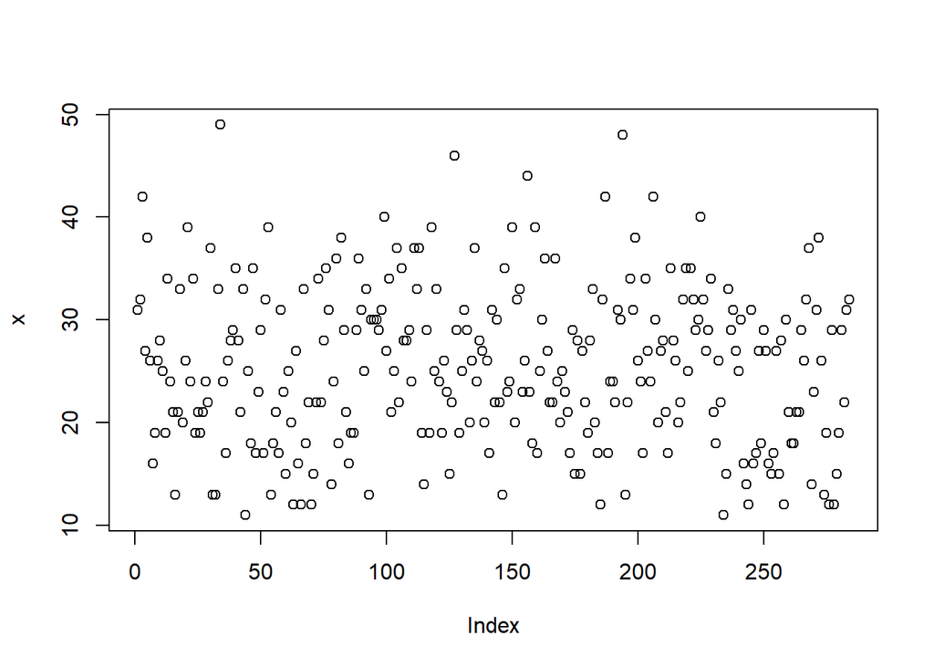

```r
x<-round( rnorm(300, mean=25, sd=9) )
x<-x[x>10]
plot(x)
```

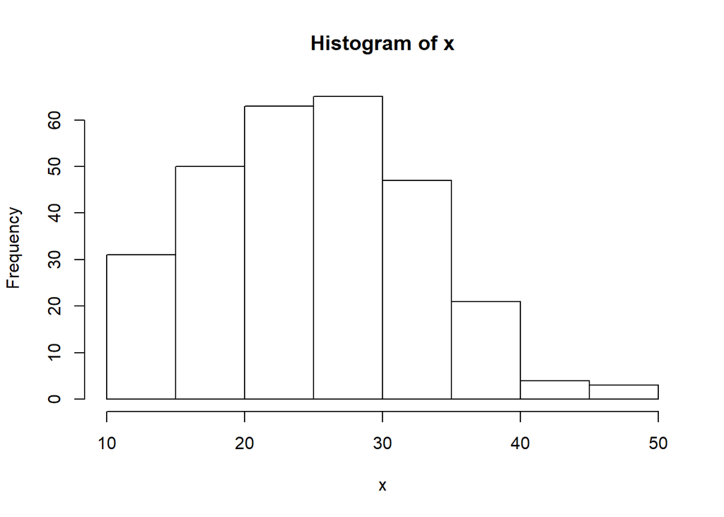

```r
hist(x)
```

```r
str(x)
```

```
##  num [1:284] 31 32 42 27 38 26 16 19 26 28 ...
```

```r
x<-as.data.frame(x)

write.csv(x, file="ages.csv",row.names=F)

#Lee solo la columna x del data.frame
ages<-read.csv("ages.csv")$x
str(ages)
```

```
##  int [1:284] 31 32 42 27 38 26 16 19 26 28 ...
```

```r
#Número de personas
length(ages)
```

```
## [1] 284
```

```r
#max,min, mean, median
max(ages)
```

```
## [1] 49
```

```r
min(ages)
```

```
## [1] 11
```

```r
mean(ages)
```

```
## [1] 25.4331
```

```r
median(ages)
```

```
## [1] 25
```

```r
#Número de personas por edad
table(ages)
```

```
## ages
## 11 12 13 14 15 16 17 18 19 20 21 22 23 24 25 26 27 28 29 30 31 32 33 34 35
##  2  8  8  4  9  6 13  9 13  9 14 16  8 14 11 13 13 12 17 10 13  9 10  7  8
## 36 37 38 39 40 42 44 46 48 49
##  4  6  4  5  2  3  1  1  1  1
```

```r
#Fecha nacimiento
birthDate <- 2017 - ages
birthDate
```

```
##   [1] 1986 1985 1975 1990 1979 1991 2001 1998 1991 1989 1992 1998 1983 1993
##  [15] 1996 2004 1996 1984 1997 1991 1978 1993 1983 1998 1996 1998 1996 1993
##  [29] 1995 1980 2004 2004 1984 1968 1993 2000 1991 1989 1988 1982 1989 1996
##  [43] 1984 2006 1992 1999 1982 2000 1994 1988 2000 1985 1978 2004 1999 1996
##  [57] 2000 1986 1994 2002 1992 1997 2005 1990 2001 2005 1984 1999 1995 2005
##  [71] 2002 1995 1983 1995 1989 1982 1986 2003 1993 1981 1999 1979 1988 1996
##  [85] 2001 1998 1998 1988 1981 1986 1992 1984 2004 1987 1987 1987 1988 1986
##  [99] 1977 1990 1983 1996 1992 1980 1995 1982 1989 1989 1988 1993 1980 1984
## [113] 1980 1998 2003 1988 1998 1978 1992 1984 1993 1998 1991 1994 2002 1995
## [127] 1971 1988 1998 1992 1986 1988 1997 1991 1980 1993 1989 1990 1997 1991
## [141] 2000 1986 1995 1987 1995 2004 1982 1994 1993 1978 1997 1985 1984 1994
## [155] 1991 1973 1994 1999 1978 2000 1992 1987 1981 1990 1995 1995 1981 1993
## [169] 1997 1992 1994 1996 2000 1988 2002 1989 2002 1990 1995 1998 1989 1984
## [183] 1997 2000 2005 1985 1975 2000 1993 1993 1995 1986 1987 1969 2004 1995
## [197] 1983 1986 1979 1991 1993 2000 1983 1990 1993 1975 1987 1997 1990 1989
## [211] 1996 2000 1982 1989 1991 1997 1995 1985 1982 1992 1982 1985 1988 1987
## [225] 1977 1985 1990 1988 1983 1996 1999 1991 1995 2006 2002 1984 1988 1986
## [239] 1990 1992 1987 2001 2003 2005 1986 2001 2000 1990 1999 1988 1990 2001
## [253] 2002 2000 1990 2002 1989 2005 1987 1996 1999 1999 1996 1996 1988 1991
## [267] 1985 1980 2003 1994 1986 1979 1991 2004 1998 2005 1988 2005 2002 1998
## [281] 1988 1995 1986 1985
```

```r
#Personas nacidas entre 1980 y 2000
birthDate[ birthDate >=1980 & birthDate <= 2000 ]
```

```
##   [1] 1986 1985 1990 1991 1998 1991 1989 1992 1998 1983 1993 1996 1996 1984
##  [15] 1997 1991 1993 1983 1998 1996 1998 1996 1993 1995 1980 1984 1993 2000
##  [29] 1991 1989 1988 1982 1989 1996 1984 1992 1999 1982 2000 1994 1988 2000
##  [43] 1985 1999 1996 2000 1986 1994 1992 1997 1990 1984 1999 1995 1995 1983
##  [57] 1995 1989 1982 1986 1993 1981 1999 1988 1996 1998 1998 1988 1981 1986
##  [71] 1992 1984 1987 1987 1987 1988 1986 1990 1983 1996 1992 1980 1995 1982
##  [85] 1989 1989 1988 1993 1980 1984 1980 1998 1988 1998 1992 1984 1993 1998
##  [99] 1991 1994 1995 1988 1998 1992 1986 1988 1997 1991 1980 1993 1989 1990
## [113] 1997 1991 2000 1986 1995 1987 1995 1982 1994 1993 1997 1985 1984 1994
## [127] 1991 1994 1999 2000 1992 1987 1981 1990 1995 1995 1981 1993 1997 1992
## [141] 1994 1996 2000 1988 1989 1990 1995 1998 1989 1984 1997 2000 1985 2000
## [155] 1993 1993 1995 1986 1987 1995 1983 1986 1991 1993 2000 1983 1990 1993
## [169] 1987 1997 1990 1989 1996 2000 1982 1989 1991 1997 1995 1985 1982 1992
## [183] 1982 1985 1988 1987 1985 1990 1988 1983 1996 1999 1991 1995 1984 1988
## [197] 1986 1990 1992 1987 1986 2000 1990 1999 1988 1990 2000 1990 1989 1987
## [211] 1996 1999 1999 1996 1996 1988 1991 1985 1980 1994 1986 1991 1998 1988
## [225] 1998 1988 1995 1986 1985
```

```r
#Mayores de 30 años
#Menores de 20
length( ages[ ages>30 ] )
```

```
## [1] 75
```

```r
length( ages[ ages<20 ] )
```

```
## [1] 72
```

```r
#Conversión
ageCategory <- ages
ages<20
```

```
##   [1] FALSE FALSE FALSE FALSE FALSE FALSE  TRUE  TRUE FALSE FALSE FALSE
##  [12]  TRUE FALSE FALSE FALSE  TRUE FALSE FALSE FALSE FALSE FALSE FALSE
##  [23] FALSE  TRUE FALSE  TRUE FALSE FALSE FALSE FALSE  TRUE  TRUE FALSE
##  [34] FALSE FALSE  TRUE FALSE FALSE FALSE FALSE FALSE FALSE FALSE  TRUE
##  [45] FALSE  TRUE FALSE  TRUE FALSE FALSE  TRUE FALSE FALSE  TRUE  TRUE
##  [56] FALSE  TRUE FALSE FALSE  TRUE FALSE FALSE  TRUE FALSE  TRUE  TRUE
##  [67] FALSE  TRUE FALSE  TRUE  TRUE FALSE FALSE FALSE FALSE FALSE FALSE
##  [78]  TRUE FALSE FALSE  TRUE FALSE FALSE FALSE  TRUE  TRUE  TRUE FALSE
##  [89] FALSE FALSE FALSE FALSE  TRUE FALSE FALSE FALSE FALSE FALSE FALSE
## [100] FALSE FALSE FALSE FALSE FALSE FALSE FALSE FALSE FALSE FALSE FALSE
## [111] FALSE FALSE FALSE  TRUE  TRUE FALSE  TRUE FALSE FALSE FALSE FALSE
## [122]  TRUE FALSE FALSE  TRUE FALSE FALSE FALSE  TRUE FALSE FALSE FALSE
## [133] FALSE FALSE FALSE FALSE FALSE FALSE FALSE FALSE  TRUE FALSE FALSE
## [144] FALSE FALSE  TRUE FALSE FALSE FALSE FALSE FALSE FALSE FALSE FALSE
## [155] FALSE FALSE FALSE  TRUE FALSE  TRUE FALSE FALSE FALSE FALSE FALSE
## [166] FALSE FALSE FALSE FALSE FALSE FALSE FALSE  TRUE FALSE  TRUE FALSE
## [177]  TRUE FALSE FALSE  TRUE FALSE FALSE FALSE  TRUE  TRUE FALSE FALSE
## [188]  TRUE FALSE FALSE FALSE FALSE FALSE FALSE  TRUE FALSE FALSE FALSE
## [199] FALSE FALSE FALSE  TRUE FALSE FALSE FALSE FALSE FALSE FALSE FALSE
## [210] FALSE FALSE  TRUE FALSE FALSE FALSE FALSE FALSE FALSE FALSE FALSE
## [221] FALSE FALSE FALSE FALSE FALSE FALSE FALSE FALSE FALSE FALSE  TRUE
## [232] FALSE FALSE  TRUE  TRUE FALSE FALSE FALSE FALSE FALSE FALSE  TRUE
## [243]  TRUE  TRUE FALSE  TRUE  TRUE FALSE  TRUE FALSE FALSE  TRUE  TRUE
## [254]  TRUE FALSE  TRUE FALSE  TRUE FALSE FALSE  TRUE  TRUE FALSE FALSE
## [265] FALSE FALSE FALSE FALSE  TRUE FALSE FALSE FALSE FALSE  TRUE  TRUE
## [276]  TRUE FALSE  TRUE  TRUE  TRUE FALSE FALSE FALSE FALSE
```

```r
ageCategory[ ages<20 ] <- "VY"
ageCategory[ ages>=20 & ages<35] <-"Y"
ageCategory[ ages>=35 & ages<50] <-"A"
ageCategory[ ages>=50 & ages<65] <-"OA"
ageCategory[ ages>=65 ] <-"O"
ageCategory
```

```
##   [1] "Y"  "Y"  "A"  "Y"  "A"  "Y"  "VY" "VY" "Y"  "Y"  "Y"  "VY" "Y"  "Y"
##  [15] "Y"  "VY" "Y"  "Y"  "Y"  "Y"  "A"  "Y"  "Y"  "VY" "Y"  "VY" "Y"  "Y"
##  [29] "Y"  "A"  "VY" "VY" "Y"  "A"  "Y"  "VY" "Y"  "Y"  "Y"  "A"  "Y"  "Y"
##  [43] "Y"  "VY" "Y"  "VY" "A"  "VY" "Y"  "Y"  "VY" "Y"  "A"  "VY" "VY" "Y"
##  [57] "VY" "Y"  "Y"  "VY" "Y"  "Y"  "VY" "Y"  "VY" "VY" "Y"  "VY" "Y"  "VY"
##  [71] "VY" "Y"  "Y"  "Y"  "Y"  "A"  "Y"  "VY" "Y"  "A"  "VY" "A"  "Y"  "Y"
##  [85] "VY" "VY" "VY" "Y"  "A"  "Y"  "Y"  "Y"  "VY" "Y"  "Y"  "Y"  "Y"  "Y"
##  [99] "A"  "Y"  "Y"  "Y"  "Y"  "A"  "Y"  "A"  "Y"  "Y"  "Y"  "Y"  "A"  "Y"
## [113] "A"  "VY" "VY" "Y"  "VY" "A"  "Y"  "Y"  "Y"  "VY" "Y"  "Y"  "VY" "Y"
## [127] "A"  "Y"  "VY" "Y"  "Y"  "Y"  "Y"  "Y"  "A"  "Y"  "Y"  "Y"  "Y"  "Y"
## [141] "VY" "Y"  "Y"  "Y"  "Y"  "VY" "A"  "Y"  "Y"  "A"  "Y"  "Y"  "Y"  "Y"
## [155] "Y"  "A"  "Y"  "VY" "A"  "VY" "Y"  "Y"  "A"  "Y"  "Y"  "Y"  "A"  "Y"
## [169] "Y"  "Y"  "Y"  "Y"  "VY" "Y"  "VY" "Y"  "VY" "Y"  "Y"  "VY" "Y"  "Y"
## [183] "Y"  "VY" "VY" "Y"  "A"  "VY" "Y"  "Y"  "Y"  "Y"  "Y"  "A"  "VY" "Y"
## [197] "Y"  "Y"  "A"  "Y"  "Y"  "VY" "Y"  "Y"  "Y"  "A"  "Y"  "Y"  "Y"  "Y"
## [211] "Y"  "VY" "A"  "Y"  "Y"  "Y"  "Y"  "Y"  "A"  "Y"  "A"  "Y"  "Y"  "Y"
## [225] "A"  "Y"  "Y"  "Y"  "Y"  "Y"  "VY" "Y"  "Y"  "VY" "VY" "Y"  "Y"  "Y"
## [239] "Y"  "Y"  "Y"  "VY" "VY" "VY" "Y"  "VY" "VY" "Y"  "VY" "Y"  "Y"  "VY"
## [253] "VY" "VY" "Y"  "VY" "Y"  "VY" "Y"  "Y"  "VY" "VY" "Y"  "Y"  "Y"  "Y"
## [267] "Y"  "A"  "VY" "Y"  "Y"  "A"  "Y"  "VY" "VY" "VY" "Y"  "VY" "VY" "VY"
## [281] "Y"  "Y"  "Y"  "Y"
```

```r
str(ageCategory)
```

```
##  chr [1:284] "Y" "Y" "A" "Y" "A" "Y" "VY" "VY" "Y" "Y" "Y" "VY" "Y" ...
```

```r
#Cuantas personas de cada categoría de edad
table(ageCategory)
```

```
## ageCategory
##   A  VY   Y
##  36  72 176
```